# PSTAT 131 Final Project

Arnav Rathnam

2024-05-15

## Introduction

In the game of soccer, positions are getting more and more complex and ambiguous. In the past, players in the same position, like fullback or strikers, would play the same way. However in the modern game, positions refer more to the position on the field rather than their impact on the field. For example, a winger like Mohamed Salah, who finds himself around the penalty area and is a primary goalscorer, brings a very different skill set than a winger like Phil Foden, who often joins in the build up play and looks to create chances for others. As teams are creating new systems that haven’t been seen before, they need to look at the specific qualities a player brings to the table rather than just a player who fills a position of need.

In this report, I will be using clustering models such as K-means clustering, Principal Component Analysis, and hierarchical clustering to group players by their skill sets rather than by positions. Statistics such as goals, assists, passes, clearances, tackles, and more will be used to create these clusters and find similarities between players across Europe’s top 5 leagues.

```r
library(ISLR)
library(ISLR2)
library(tidyverse)
library(tidymodels)
```

```r
library(readr)
library(corrr)
library(corrplot)
library(themis)
library(discrim)
library(klaR)
library(gghighlight)
library(tune)
library(pals)
tidymodels_prefer()
```

## The Data

The data used in this report comes from Football Reference’s European top 5 Leagues dataset (https://fbref.com/en/comps/Big5/stats/players/Big-5-European-Leagues-Stats). I scraped the data from the different tabs of data included in the website and selected the data that I was interested in.

```r
require("dplyr")
library(janitor)
#Scraping data from online
standard_stats_raw = xml2::read_html("https://fbref.com/en/comps/Big5/stats/players/Big-5-European-Leagues-Stats") %>% rvest::html_nodes("#stats_standard") %>% rvest::html_table()
standard_stats_raw = standard_stats_raw[[1]]

shooting_stats_raw = xml2::read_html("https://fbref.com/en/comps/Big5/shooting/players/Big-5-European-Leagues-Stats") %>% rvest::html_nodes("#stats_shooting") %>% rvest::html_table()
shooting_stats_raw = shooting_stats_raw[[1]]

passing_stats_raw = xml2::read_html("https://fbref.com/en/comps/Big5/passing/players/Big-5-European-Leagues-Stats") %>% rvest::html_nodes("#stats_passing") %>% rvest::html_table()
passing_stats_raw = passing_stats_raw[[1]]

possession_stats_raw = xml2::read_html("https://fbref.com/en/comps/Big5/possession/players/Big-5-European-Leagues-Stats") %>% rvest::html_nodes("#stats_possession") %>% rvest::html_table()
possession_stats_raw = possession_stats_raw[[1]]

defense_stats_raw = xml2::read_html("https://fbref.com/en/comps/Big5/defense/players/Big-5-European-Leagues-Stats") %>% rvest::html_nodes("#stats_defense") %>% rvest::html_table()
defense_stats_raw = defense_stats_raw[[1]]


#Making row 1 the variable names of the datasets
standard_stats<-standard_stats_raw %>%
  row_to_names(1)

shooting_stats<-shooting_stats_raw %>%
  row_to_names(1)

passing_stats_long<-passing_stats_raw %>%
  row_to_names(1)
passing_stats<-passing_stats_long %>%
  select(1:12)

possession_stats<-possession_stats_raw %>%
  row_to_names(1) %>%
  rename('TakeAtt'=Att)

defense_stats_long<-defense_stats_raw %>%
  row_to_names(1)
defense_stats<-defense_stats_long %>%
  select(1:12,19:26)
```

I combined the data from the different tabs into one complete data set. To look get more information about the statistics that I have chosen, look at the data.txt file.

```r
#Combining all wanted variables from the datasets (Player, `90s`, `G-PK`, npxG, Ast, xAG, Att, `Cmp%`, PrgP, PrgC, TakeAtt, `Succ%`, Tkl, Int, Blocks, Clr)
player_stats<-cbind(standard_stats, passing_stats, possession_stats, defense_stats) %>%
  select(2,4,12,14,16,22,23,25,26,49,50,67,69,92,95,98,100) %>%
  filter(!Player=="Player")

player_stats <- player_stats %>%
  mutate_at(c('90s', 'G-PK', 'npxG', 'Ast', 'xAG', 'Att', 'Cmp%', 'PrgP', 'PrgC', 'TakeAtt', 'Succ%','Tkl', 'Int', 'Blocks', 'Clr'), as.numeric)
```

Taking a look at the distribution of 90s played, we can see there is a significant drop off.

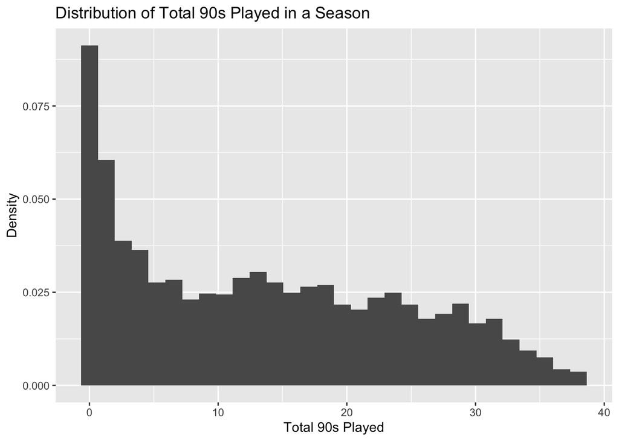

```r
player_stats %>%
  ggplot(aes(x=`90s`)) +
  geom_histogram(aes(y=after_stat(density)), bins = 30) +
  labs(y = "Density", x = "Total 90s Played", title = "Distribution of Total 90s Played in a Season")
```

I determined that a good cutoff for 90s played would be 10 90s played or 900 total minutes. This ensures that the players used in the algorithm are players that are playing consistently.

```r
#filter players who have played less than 10 90s.

player_stats <- player_stats %>%
  filter(`90s` >= 10) %>%
  filter(`Succ%` > 0)
```

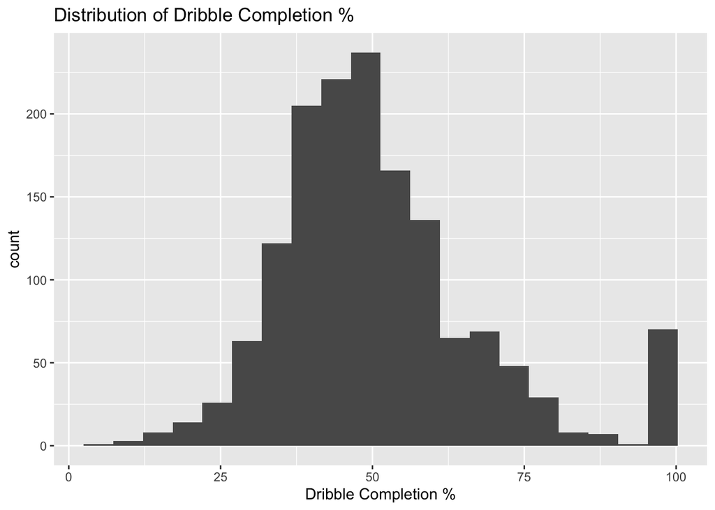

```r
player_stats %>%
  ggplot((aes(x=`Succ%`))) +
  geom_histogram(bins = 20) +
  labs( x = "Dribble Completion %", title = "Distribution of Dribble Completion %")
```

Looking at the distribution of dribble completion percentage, there seems to be an unusual amount of players that have 100% success rates. This seems like an unreasonable amount for an active player to achieve. Lets take a closer look.

```r
sorted_succ <- player_stats %>%
  dplyr::arrange(desc(`Succ%`)) %>%
  select(Player, Pos, `Succ%`)
head(sorted_succ)
```

```
##                Player Pos Succ%
## 1     Alphonse Areola  GK   100
## 2     Augusto Batalla  GK   100
## 3        Marcin Bułka  GK   100
## 4        Craig Dawson  DF   100
## 5 Michele Di Gregorio  GK   100
## 6           Eric Dier  DF   100
```

It seems as though the majority of players that have a 100% success rate are goalkeepers. For the purpose of this report, I will remove goalkeepers from the clustering algorithms to avoid outliers.

```r
player_stats<-player_stats %>%
  filter(Pos!='GK')
```

I converted all of the counting stats to a per 90 basis in order to account for players who’s reason for having high statistics is solely due to their minutes played.

```r
#convert all stats to per 90 basis
player_stats_p90 <- player_stats %>%
  mutate(across(c(4:10, 12, 14:17), .fns = ~./`90s`))

#Rounding all values to 2 decimal points and replacing NA values with 0
player_stats_p90 <- player_stats_p90%>%
  mutate(across(where(is.numeric), round, digits=2)) %>%
  mutate_all(~replace(., is.na(.), 0))
```

Looking at the correlation plot, all the data seems to be in order. All of the statistics that I would expect to be correlated are correlated.

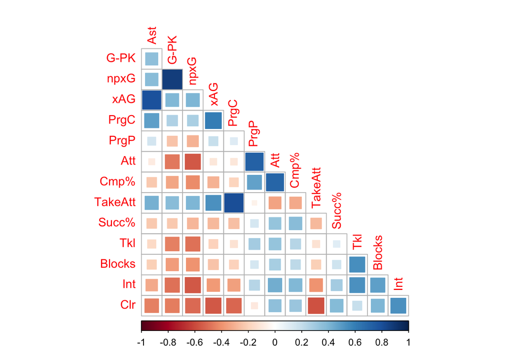

```r
player_stats_p90 %>%
  select(where(is.numeric), -`90s`) %>%
  cor(use='complete.obs') %>%
  corrplot(type='lower', diag=F,method='square')
```

## K-Means Clustering

The first step in the K-Means Clustering process is to figure out how many clusters to group the players into. The optimal k will do the best job at both ensuring observations within the same cluster are as similar as possible and observations in different clusters are as different as possible. Here I apply the k-means algorithm for 1 to 25 clusters and observe their sum of squares value.

```r
#Scaling Stats for K-Means
number_stats <- player_stats_p90 %>%
  select(-Player, -`90s`, -Pos) %>%
  scale()
```

```r
set.seed(3333)
MAX_K <- 25
sse <- c()

for (k in 1:MAX_K) {
  algo_k <- kmeans(number_stats, centers=k, nstart=22, iter.max = 20)
  sse <- c(sse, algo_k$tot.withinss)
}
```

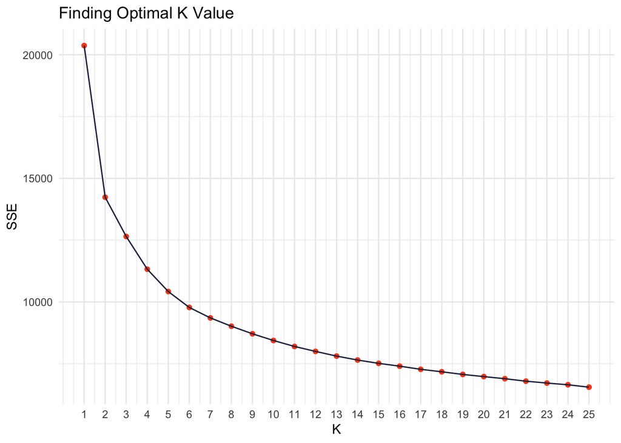

```r
tibble(k = 1:MAX_K, SSE = sse) %>%
  ggplot(aes(x=k, y=SSE)) +
  geom_point(color="#F84C1E") + geom_line(color="#232D4B") +
  labs(x = "K", y = "SSE", title = "Finding Optimal K Value") +
  scale_x_continuous(breaks=seq(1, MAX_K, 1)) +
  theme_minimal()
```

To me it seems like the graph levels off at around 16 clusters which is what I will go with.

Now we can visualize the clusters that were made with the K-Means algorithm.

```r
K <- 16

kmeans16 <- kmeans(number_stats, K, nstart=20, iter.max = 20)
km_centers <- as.data.frame(kmeans16$centers)

km_centers$Cluster <- c('Cluster 1', 'Cluster 2', 'Cluster 3',
                       'Cluster 4', 'Cluster 5', 'Cluster 6',
                       'Cluster 7', 'Cluster 8', 'Cluster 9',
                       'Cluster 10', 'Cluster 11', 'Cluster 12',
                       'Cluster 13', 'Cluster 14', 'Cluster 15',
                       'Cluster 16')

km_centers <- km_centers %>%
  pivot_longer(!Cluster, names_to = 'names', values_to = 'values')

# reset the order of clusters for plotting (cluster 10 would default to come after cluster 1 and before cluster 2)
km_centers$Cluster <- factor(km_centers$Cluster, levels=c('Cluster 1', 'Cluster 2', 'Cluster 3',
                                                          'Cluster 4', 'Cluster 5', 'Cluster 6',
                                                          'Cluster 7', 'Cluster 8', 'Cluster 9',
                                                          'Cluster 10', 'Cluster 11', 'Cluster 12',
                                                          'Cluster 13', 'Cluster 14', 'Cluster 15',
                                                          'Cluster 16'))
```

[figure not shown]

```r
km_centers %>%
  ggplot(aes(x=names, y=values, color=Cluster)) +
  geom_point(color="#232D4B") + # color points
  gghighlight(Cluster=='Cluster 16', use_direct_label = FALSE) + # highlight cluster 1
  labs(x = "Predictor", y = "Cluster Center",  # axis labels
       title = "Visualizing K-Means Cluster Makeups", # plot title
       subtitle = "Cluster 1") +  # plot subtitle
  theme_minimal() + # add themes
  theme(legend.position = "none", # manually adjust themes
        axis.text.x = element_text(angle=45, size=10))
```

Lets take a look at all of the clusters

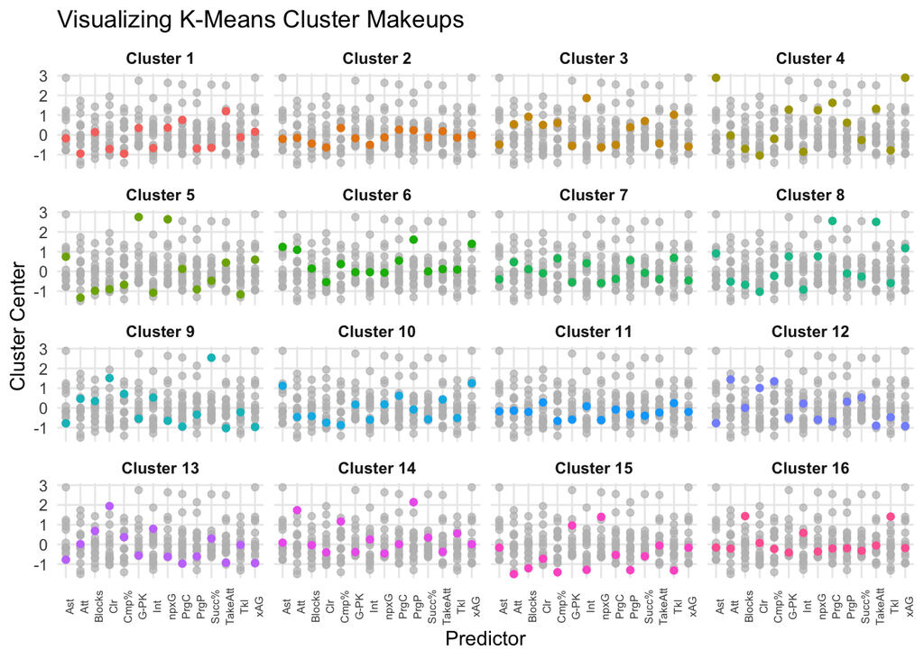

```r
km_centers %>%
  ggplot(aes(x=names, y=values, color=Cluster)) +
  geom_point() + # plot points # color points
  gghighlight(use_direct_label = FALSE) + # highlight each cluster
  facet_wrap(~ Cluster, ncol=4) + # create seperate plots for each cluster
  labs(x = "Predictor", y = "Cluster Center",
       title = "Visualizing K-Means Cluster Makeups") +
  theme_minimal() +
  theme(legend.position = "none", strip.text = element_text(face='bold'),
        axis.text.x = element_text(angle=90, size=6), # alter axis text
        panel.grid.minor = element_blank())
```

Looking at the plots of all the clusters, we can name these clusters in terms of playstyles.

Cluster 2: Calm Center Backs - notable players: Mathijs De Ligt, Keven Schlotterbeck

Cluster 3: No-Nonsense Center Backs - notable players: Sergio Ramos, Dan Burn, Ben Mee

Cluster 7: Do-it-all Players - notable players: Antoine Griezmann, Douglas Luiz, Khephren Thuram

Cluster 9: Ball-playing Defenders - Thiago Silva, John Stones, Virgil Van Dijk

Cluster 10: ‘Mid’ - no notable players

Cluster 12: Possession Keepers - notable players: Frenkie De Jong, Jorginho, Declan Rice

## Principle Component Analysis (PCA)

PCA is an unsupervised dimensionality reduction technique. This means that we can use PCA to manufacture new predictor variables in order to display the data within 2 dimensions. We first need to determine the amount of variance that is explained bay each principle component.

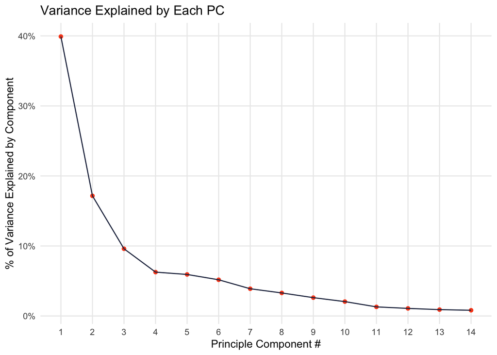

```r
pca <- prcomp(number_stats) # perform Principle Component Analysis
pca_summary <- summary(pca) # summary of PCA model

# plot % of variance between players explained by each subsequent PC
tibble(imp = pca_summary$importance[2,], n = 1:length(imp)) %>% # get importance scores for PCA summary
  ggplot(aes(x=n, y=imp)) +
  labs(x = 'Principle Component #', y = '% of Variance Explained by Component',
       title = 'Variance Explained by Each PC') +
  geom_point(color="#F84C1E") + geom_line(color="#232D4B") +
  theme_minimal() + scale_x_continuous(breaks=seq(1, 20, 1)) + # set x-axis
  scale_y_continuous(labels=scales::percent) + # change y-axis from proportion to percentage
  theme(panel.grid.minor.x = element_blank(), panel.grid.minor.y = element_blank())
```

We can use the first two principle components as they explain the highest percentage of variance. We can combine this with the K-means algorithm to visualize the difference between the clusters in two dimensions.

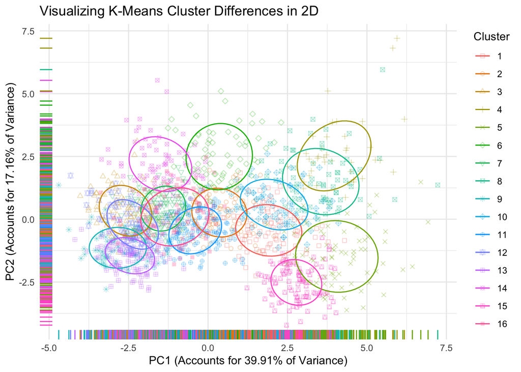

```r
pc2 <- as.data.frame(pca$x[,1:2]) # extract first two PCs
pc2$Cluster <- as.factor(kmeans16$cluster) # add player clusters
cluster1_var <- round(pca_summary$importance[2,1], 4) * 100 # get variance explained by cluster 1
cluster2_var <- round(pca_summary$importance[2,2], 4) * 100 # get variance explained by cluster 2

# how different are the clusters when scaled down to two dimensions?
pc2 %>%
  ggplot(aes(x=PC1, y=PC2, color=Cluster, shape=Cluster)) +
  geom_point(alpha=0.3) +
  scale_fill_discrete() +
  geom_rug() + # great way to visualize points on a single axis
  theme_minimal() + stat_ellipse(level=(2/3)) + # set ellipse value to one standard deviation
  scale_shape_manual(values=seq(0,15)) +
  labs(x = paste0('PC1 (Accounts for ', cluster1_var, '% of Variance)'), # define cluster 1 % of variance
       y = paste0('PC2 (Accounts for ', cluster2_var, '% of Variance)'), # define cluster 2 % of variance
       title = 'Visualizing K-Means Cluster Differences in 2D')
```

## Hierarchical Clustering

As we have already created and scaled our data set, we can go straight into performing hierarchical clustering. First, we can compare the different types of hierarchical clustering: complete, average, and single.

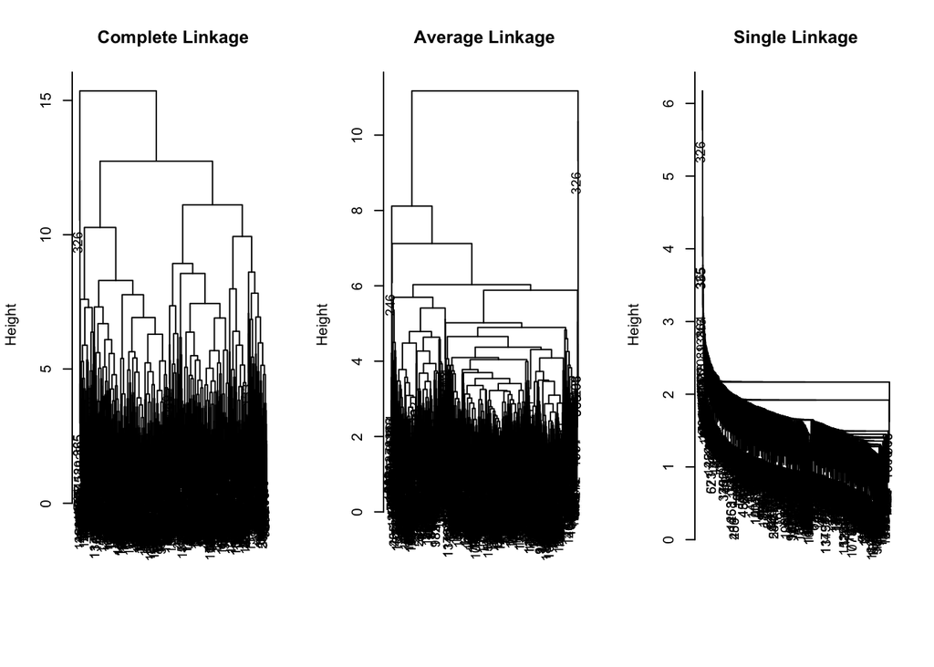

```r
hc.complete <- hclust(dist(number_stats), method = "complete")
hc.average <- hclust(dist(number_stats), method = "average")
hc.single <- hclust(dist(number_stats), method = "single")


par(mfrow = c(1, 3))
plot(hc.complete, main = "Complete Linkage", xlab = "", sub = "", cex = .9)
plot(hc.average, main = "Average Linkage", xlab = "", sub = "", cex = .9)
plot(hc.single, main = "Single Linkage", xlab = "", sub = "", cex = .9)
```

As seen, the different hierarchical clustering methods definitely achieve different results. Both the Average and Single Linkage appear to be quite unbalanced. Therefore we will be using the Complete Linkage model.

We can cut the dendrogram at a hieght to yield a specific amount of clusters. Because I used 16 clusters for the K-Means model, I picked the same amount of clusters for the Hierarchical Clustering model.

```r
hc.clusters <- cutree(hc.complete, k = 16)


player_hc <- cbind(player_stats, cluster=hc.clusters)

player_hc %>%
  group_by(cluster) %>%
  summarize(count=n())
```

```
## # A tibble: 16 × 2
##    cluster count
##      <int> <int>
##  1       1   330
##  2       2    39
##  3       3   205
##  4       4   163
##  5       5   136
##  6       6    90
##  7       7    44
##  8       8   104
##  9       9   191
## 10      10    72
## 11      11    50
## 12      12    12
## 13      13    12
## 14      14     1
## 15      15     2
## 16      16     5
```

While looking at the amount of players grouped into each cluster, we can notice something very interesting happening. Some of the clusters have very few players, specifically 14, 15, and 16 which have 1, 2, and 5 players respectively.

Let’s look at which player was clustered into his own category.

```r
player_hc %>%
  filter(cluster==14) %>%
  select(Player, cluster)
```

```
##            Player cluster
## 1 Kevin De Bruyne      14
```

```r
cluster8 <- tibble(name=player_stats_p90$Player, Assists=player_stats_p90$Ast, `Expected Assists`=player_stats_p90$xAG) %>%
  dplyr::arrange(desc(`Expected Assists`))

head(cluster8)
```

```
## # A tibble: 6 × 3
##   name            Assists `Expected Assists`
##   <chr>             <dbl>              <dbl>
## 1 Kevin De Bruyne    0.74               0.85
## 2 Marco Asensio      0.4                0.47
## 3 Thomas Müller      0.49               0.46
## 4 Leroy Sané         0.46               0.46
## 5 Mohamed Salah      0.35               0.42
## 6 Michael Olise      0.42               0.41
```

```r
par(mfrow = c(1, 2))
player_hc %>%
  filter(cluster==15) %>%
  select(Player, cluster)
```

```
##            Player cluster
## 1 Ousmane Dembélé      15
## 2     Jeremy Doku      15
```

```r
player_hc %>%
  filter(cluster==16) %>%
  select(Player, cluster)
```

```
##                Player cluster
## 1     Frenkie de Jong      16
## 2          Toni Kroos      16
## 3               Rodri      16
## 4        Granit Xhaka      16
## 5 Oleksandr Zinchenko      16
```

A similar thing can be seen with the players in cluster 15 and 16 which can be found at the top of the charts for dribbling and passing respectively. Although not to the extent of De Bruyne.

```r
sorted_dribbles <- tibble(name=player_stats_p90$Player, `Dribbles Attempted`=player_stats_p90$TakeAtt, `Success %`=player_stats_p90$`Succ%`) %>%
  dplyr::arrange(desc(`Dribbles Attempted`))

head(sorted_dribbles)
```

```
## # A tibble: 6 × 3
##   name                `Dribbles Attempted` `Success %`
##   <chr>                              <dbl>       <dbl>
## 1 Jeremy Doku                         9.55        51.5
## 2 Vinicius Júnior                     8.5         36.9
## 3 Jamie Bynoe-Gittens                 8.39        43.4
## 4 Ousmane Dembélé                     8.32        46.8
## 5 Brajan Gruda                        8.13        46.6
## 6 Mohammed Kudus                      8.01        56.1
```

```r
sorted_passes <- tibble(name=player_stats_p90$Player, `Passes`=player_stats_p90$Att) %>%
  dplyr::arrange(desc(`Passes`))

head(sorted_passes)
```

```
## # A tibble: 6 × 2
##   name           Passes
##   <chr>           <dbl>
## 1 Rodri            112.
## 2 Toni Kroos       106.
## 3 Marquinhos       106.
## 4 Granit Xhaka     105.
## 5 Lewis Dunk       101.
## 6 Milan Škriniar   101.
```

## Conclusion

Throughout this report, we have observed different ways to cluster soccer players into different playstyles. Combining the results with my knowledge of soccer, I have determined that the hierarchical clustering model performed the best. Although it resulted in a few small clusters, those clusters were reserved for the best of the best players which makes a lot of sense.

This report has some practical applications in the soccer world as well. As teams sell players and look to acquire new ones, they can examine which players possess the same skills as the departed player and adequately replace them. Although decisions should not be based solely off this model, it can definitely be used as a base to then do further research into specific players.